# Template Interrupted time series

João Vítor Souza

Loading packages and sample data set.

```r
library(astsa); library(forecast); library(dplyr); library(zoo); library(comprehenr);
library(ggplot2); library(scales); library(gtsummary); library(foreign);library(tsModel); library("lmtest") ; library("Epi");library("splines") ; library("vcd")
data <- read.csv("sicily.csv")
```

## Sample data set

The **Sicily** dataset consistis of Acute Coronary Events (ACEs) registerd in Sicily befor and after the **ban of smoking in public places**. It is available as a suplementary material from the publication [Interrupted time series regression for the evaluation of public health interventions: a tutorial](https://academic.oup.com/ije/article/46/1/348/2622842#112547752).

### Variables of interest

- year: year of the event;
- month: coded in ordinal number going from 1 (Jan) to 12 (Dec);
- aces: sum of acute coronary events registered in that month;
- time: numeric variable continuously counting how many periods have passed since the beginning of the study;
- smokban: dummy variable indicating whether the period is before (0) or after (1) the ban of smoking in public places;
- pop: population of Sicily;
- stdpop: standardized population of Sicily.

```r
head(data)
```

|  | year | month | aces | time | smokban | pop | stdpop |
| --- | --- | --- | --- | --- | --- | --- | --- |
| 1 | 2002 | 1 | 728 | 1 | 0 | 364277.4 | 379875.3 |
| 2 | 2002 | 2 | 659 | 2 | 0 | 364277.4 | 376495.5 |
| 3 | 2002 | 3 | 791 | 3 | 0 | 364277.4 | 377040.8 |
| 4 | 2002 | 4 | 734 | 4 | 0 | 364277.4 | 377116.4 |
| 5 | 2002 | 5 | 757 | 5 | 0 | 364277.4 | 377383.4 |
| 6 | 2002 | 6 | 726 | 6 | 0 | 364277.4 | 374113.1 |

## Explore ACE events

```r
### The months variable is coded as 1, 2 ... and I need it to be 01, 02..
numbers <- c()
for (i in as.character(data$month)){
  if (nchar(i) ==1){
    numbers <- c(numbers, paste("0",i, sep=""))
  }
  else {
    numbers <- c(numbers, i)
  }
}
# Creating a date column

data$date <- as.POSIXct(paste(data$year, numbers, "01",sep='-'), format="%Y-%m-%d")
data$smokban <- factor(data$smokban, levels=c(0,1),
                       labels=c("Before","After"))
```

Plotting the series of cases

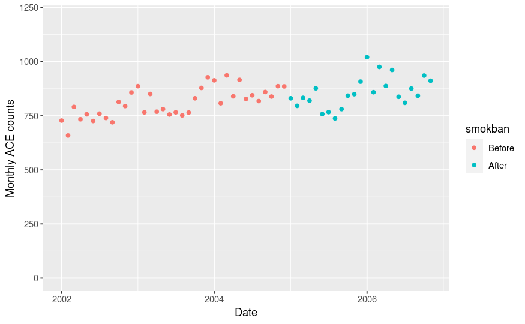

```r
data %>%
  ggplot(aes(x=date,y=aces, color=smokban)) +
  geom_point() + scale_fill_discrete(name="") + ylim(0,1200) + labs(x="Date", y="Monthly ACE counts")
```

## Summarizing events

In the table below we do a simple comparison of median ACE events before and after the Ban of Smoking in public places. In addition to that, we create a variable that accounts for population growth (rate of ACEs/100,000). We can see how the difference is lost when we consider the growth of the population

```r
data$rate <- with(data, aces/stdpop*10^5)

var_names <- list(rate~"Rate ACE",
                  aces~"Raw ACE")
stat <-  all_continuous() ~ c("{median} ({p25}, {p75})",
                              "{min}, {max}", "{mean}, {sd}")
types <- list(all_continuous() ~ "continuous2")

data %>%
  dplyr::select(aces,rate,smokban) %>%
  tbl_summary(by=smokban, label=var_names,statistic=stat, type=types,) %>%
  add_p() %>% bold_labels() %>% bold_p() %>%
  as_gt() %>% gt::tab_header(gt::md("**ACE events before and after the smoke ban**"))
```

**ACE events before and after the smoke ban**

| **Characteristic** | **Before**, N = 36 | **After**, N = 23 | **p-value**<sup>1</sup> |
| --- | --- | --- | --- |
| Raw ACE |  |  | 0.027 |
| Median (IQR) | 811 (759, 858) | 843 (815, 898) |  |
| Range | 659, 937 | 738, 1,021 |  |
| Mean, SD | 811, 68 | 858, 72 |  |
| Rate ACE |  |  | 0.2 |
| Median (IQR) | 213 (201, 225) | 218 (210, 231) |  |
| Range | 175, 244 | 191, 261 |  |
| Mean, SD | 213, 17 | 221, 18 |  |

<sup>*1*</sup> Wilcoxon rank sum test; Wilcoxon rank sum exact test

## Segmented regression

Simplest and easiest way to model an ITS. Briefly, segmented (or *piecewise*) regression fits two regressions: **before** and **after** the intervention.

Notes: * Here we are proposing a level change. This is why the smokban variable is used as a dummy that changes to 1 after the ban. Other assumptions should take different modelling; * Here we use an offset as a log of the stdpop because the poisson distribution is not suited for a y variable that is a rate; * The poisson distribution is ideal for TS as we usually work with counts. The Poisson distribution has a positive and integer basis as you could not have something like -2 or 3.5 cases registered in a period.

```r
model1 <- glm(aces ~ offset(log(stdpop)) + smokban + time, family=poisson, data)
summary(model1)
```

```
Call:
glm(formula = aces ~ offset(log(stdpop)) + smokban + time, family = poisson,
    data = data)

Deviance Residuals:
    Min       1Q   Median       3Q      Max
-3.4336  -1.4432  -0.4431   1.2735   5.0701

Coefficients:
               Estimate Std. Error  z value Pr(>|z|)
(Intercept)  -6.2431509  0.0111894 -557.955  < 2e-16 ***
smokbanAfter -0.1116284  0.0172248   -6.481 9.13e-11 ***
time          0.0049450  0.0004992    9.905  < 2e-16 ***
---
Signif. codes:  0 ‘***’ 0.001 ‘**’ 0.01 ‘*’ 0.05 ‘.’ 0.1 ‘ ’ 1

(Dispersion parameter for poisson family taken to be 1)

    Null deviance: 308.52  on 58  degrees of freedom
Residual deviance: 197.31  on 56  degrees of freedom
AIC: 708.03

Number of Fisher Scoring iterations: 3
```

With the raw summary of the model we see that our estimate shows that ban of smoking caused a reduction of ~11% in the ACE events (p<0.001).

Making a pretty table

```r
model1 %>%
  tbl_regression(label=list(smokban~"Smoke ban", time~"Time")) %>%
  bold_p() %>%
  bold_labels() %>% as_gt() %>% gt::tab_header("Segmented regression model")
```

Segmented regression model

| **Characteristic** | **log(IRR)**<sup>1</sup> | **95% CI**<sup>1</sup> | **p-value** |
| --- | --- | --- | --- |
| Smoke ban |  |  |  |
| Before | — | — |  |
| After | -0.11 | -0.15, -0.08 | <0.001 |
| Time | 0.00 | 0.00, 0.01 | <0.001 |

<sup>*1*</sup> IRR = Incidence Rate Ratio, CI = Confidence Interval

```r
datanew <- data.frame(stdpop=mean(data$stdpop),
                      smokban=factor(rep(c(0,1),c(36,24)),
                                     levels=c(0,1),
                                     labels=c("Before", "After")),
                      time= 1:60,
                      month=rep(01:12,5),
                      year=c(rep(2002, 12),
                             rep(2003, 12),
                             rep(2004, 12),
                             rep(2005, 12),
                             rep(2006, 12)))
pred1 <- predict(model1, type="response", datanew)

getDates <- function(month, year){
  numbers <- c()
  for (i in as.character(month)){
    if (nchar(i) ==1){
      numbers <- c(numbers, paste("0",i, sep=""))
    }
    else {
      numbers <- c(numbers, i)
    }
  }
  date <- as.POSIXct(paste(year, month, "01",sep='-'), format="%Y-%m-%d")
  return(date)
  }

datanew$date <- getDates(datanew$month, datanew$year)

datanew$aces <- pred1


# Counter-factual
data.cont <- data.frame(stdpop=mean(data$stdpop),
                        smokban=factor(rep(0,c(60)),
                                     levels=c(0,1),
                                     labels=c("Before", "After")),
                        time= 1:60,
                        month=rep(01:12,5),
                        year=c(rep(2002, 12),
                             rep(2003, 12),
                             rep(2004, 12),
                             rep(2005, 12),
                             rep(2006, 12)))
data.cont$date <- getDates(data.cont$month, data.cont$year)
data.cont$aces <- predict(model1, type="response", data.cont)
```

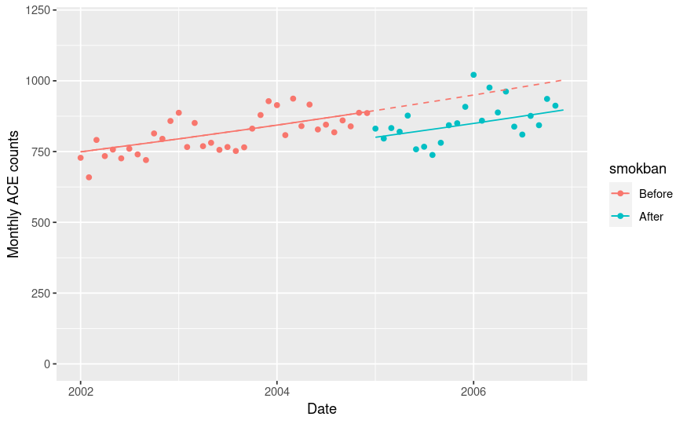

```r
data %>%
  ggplot(aes(x=date,y=aces, color=smokban)) +
  geom_point() +
  geom_line(data=datanew) +
  geom_line(data=data.cont, linetype = "dashed") +
  scale_fill_discrete(name="") + ylim(0,1200) + labs(x="Date", y="Monthly ACE counts")
```